# Kapitel 6 (nur R)

Matthias Ziegler

20 1 2017

Dies ist ein Beispiel wie ein html zu jedem Buchkapitel aussehen könnte. Wir haben uns dabei darauf beschränkt, hier nur die Abschnitte wiederzugeben, die zeigen, wie etwas in R geht.

# 1 Kapitel 6: Verfahren zur prüfung von Mittelwertsunterschieden bei mehr als zwei Gruppen

## 1.1 Einfaktorielle ANOVA

```r
setwd("/Users/Matthias/Dropbox/Statistikbuch 2. Auflage/Kapitel 6/finale Versionen")
library(foreign)
anova_ein <- read.spss("ANOVA omW voll.sav", to.data.frame=TRUE, use.value.labels=TRUE)
```

```
## re-encoding from CP1252
```

```r
head(anova_ein)
```

```
##   vpn         gruppe     b
## 1   7    Faking Good 49.33
## 2   8     Faking Bad 35.00
## 3   9     Faking Bad 24.33
## 4  10     Faking Bad 38.00
## 5  11    Faking Good 59.00
## 6  12 Kontrollgruppe 59.67
```

Nun sind die Daten eingelesen. Schauen wir auf die deskriptiven Statistiken.

```r
library(psych)
desc_anova_ein <- describeBy(anova_ein$b, anova_ein$gruppe, mat=T)
desc_anova_ein
```

```
##     item         group1 vars  n     mean        sd median  trimmed
## X11    1    Faking Good    1 37 64.07162  7.347935  63.00 63.98903
## X12    2     Faking Bad    1 41 38.78854 15.584761  38.33 39.11121
## X13    3 Kontrollgruppe    1 41 62.68244  5.791236  61.33 62.51455
##           mad   min   max range        skew    kurtosis        se
## X11  7.413000 49.33 81.33 32.00  0.14967276 -0.58680790 1.2079930
## X12 20.756400  6.00 63.00 57.00 -0.05982304 -1.12585919 2.4339308
## X13  3.958542 50.00 75.67 25.67  0.33655540 -0.09339176 0.9044392
```

Nun können wir die Voraussetzungen prüfen.

```r
#Levene Test
library(lawstat)
Levene <- levene.test(anova_ein$b, anova_ein$gruppe, location="mean")
print(Levene)
```

```
##
##  classical Levene's test based on the absolute deviations from the
##  mean ( none not applied because the location is not set to median
##  )
##
## data:  anova_ein$b
## Test Statistic = 24.276, p-value = 1.56e-09
```

```r
#Brown-Forsythe
Forsythe <- levene.test(anova_ein$b, anova_ein$gruppe, location ="median")
print(Forsythe)
```

```
##
##  modified robust Brown-Forsythe Levene-type test based on the
##  absolute deviations from the median
##
## data:  anova_ein$b
## Test Statistic = 23.65, p-value = 2.429e-09
```

```r
#Hartley-F max
#eine eigene Funktion
fmax <- function(x, uv1, uv2, av, p){
  library(reshape2)
  # für einfaktorielle:
  if (uv2=="") { # begin ifelse cond. 1
    Varianzen <- acast(x, uv1, value.var=av, var) # berechnet die Var in jeder Gruppe
  }
  else { # cont. ifelse for cond. 2
    # für zweifaktorielle:
    # zunächst daten als reiner df:
    ex.data <- x[c(uv1, uv2, av)]
    # need colnames as numbers for acast function
    pos_uv1 <- grep(uv1, colnames(ex.data))
    pos_uv2 <- grep(uv2, colnames(ex.data))
    # get variances
    Varianzen <- acast(ex.data, list(names(ex.data)[pos_uv1], names(ex.data)[pos_uv2]), value.var=av, var)
  } # close loop and cont.

  # Größte und kleinste Varianz auslesen und teilen für Fmax
  Varmax <- max(Varianzen) # größte Varianz
  Varmin <- min(Varianzen) # kleinste Varianz
  Fmax <- Varmax/Varmin # berechnet F max
  # Hartley_F
  library(SuppDists) #Das Paket SuppDists wird geöffnet, da wir es später für die Funktion qmaxFratio benötigen
  k <- length(Varianzen) # Anzhal der Gruppen
  Hartley_F <- qmaxFratio(p=p, #gewünschte Sicherheitswahrscheinlichkeit
                          df=((nrow(x)/k)-1), # Anzahl der Personen pro Gruppe minus 1
                          k=k) # Anzahl der Gruppen
  # finale Entscheidung
  Vergleich <- Fmax>Hartley_F # Vergleich der beiden Werte
  Werte <- data.frame(Varmin, Varmax, Fmax, Hartley_F) # as data frame
  colnames(Werte) <- c("Varmin", "Varmax", "Fmax", "Hartley_F")
  if(Vergleich=="FALSE") Ergebnis <- "Varianzhomogenität liegt vor" else
    Ergebnis <- "Varianzhomogenität liegt nicht vor"
  # print results
  print(Ergebnis)
  print(Werte)
}
fmax(x=anova_ein, uv1="gruppe", uv2="", av="b", p=.95)
```

```
## [1] "Varianzhomogenität liegt nicht vor"
##     Varmin   Varmax     Fmax Hartley_F
## 1 33.53842 242.8848 7.241987  2.166224
```

Nun folgt die eigentliche ANOVA.

```r
library(afex)
out1 <- aov_car(b~gruppe+Error(vpn), data=anova_ein, return="Anova")
```

```
## Contrasts set to contr.sum for the following variables: gruppe
```

```r
out2 <- aov_car(b~gruppe+Error(vpn), data=anova_ein, anova_table = list(es = "ges"))
```

```
## Contrasts set to contr.sum for the following variables: gruppe
```

```r
out1
```

```
## Anova Table (Type III tests)
##
## Response: dv
##             Sum Sq  Df  F value    Pr(>F)
## (Intercept) 361499   1 3225.525 < 2.2e-16 ***
## gruppe       16238   2   72.444 < 2.2e-16 ***
## Residuals    13001 116
## ---
## Signif. codes:  0 '***' 0.001 '**' 0.01 '*' 0.05 '.' 0.1 ' ' 1
```

```r
out2
```

```
## Anova Table (Type 3 tests)
##
## Response: b
##   Effect     df    MSE         F ges p.value
## 1 gruppe 2, 116 112.07 72.44 *** .56  <.0001
```

```r
library(pwr)
pwr.f2.test(u=2, v=116, sig.level=.05, f2=.56/(1-.56))
```

```
##
##      Multiple regression power calculation
##
##               u = 2
##               v = 116
##              f2 = 1.272727
##       sig.level = 0.05
##           power = 1
```

Schauen wir uns eine robuste Alternative an.

```r
library(stats)
Welch <- oneway.test(b~gruppe, data=anova_ein, var.equal=F)
print(Welch)
```

```
##
##  One-way analysis of means (not assuming equal variances)
##
## data:  b and gruppe
## F = 46.126, num df = 2.000, denom df = 70.549, p-value = 1.547e-13
```

Um zu vermeiden, dass es zu Fehlern kommt, nehmen wir alle Pakete raus.

```r
detachAllPackages <- function() {
basic.packages <- c("package:stats","package:graphics","package:grDevices","package:utils","package:datasets","package:methods","package:base")
package.list <- search()[ifelse(unlist(gregexpr("package:",search()))==1,TRUE,FALSE)]
package.list <- setdiff(package.list,basic.packages)
if (length(package.list)>0)  for (package in package.list) detach(package, character.only=TRUE)
}
detachAllPackages()
```

## 1.2 Kruskal-Wallis

Auch hier erst die deskriptiven Statistiken

```r
anova_ein$b_rank <- rank(anova_ein$b)
library(psych)
desc_kruskal1 <- psych::describe(anova_ein$b)
desc_kruskal1
```

```
##    vars   n  mean    sd median trimmed  mad min   max range skew kurtosis
## X1    1 119 54.88 15.74     60   56.65 9.38   6 81.33 75.33 -1.1     0.48
##      se
## X1 1.44
```

```r
desc_kruskal2 <- describeBy(anova_ein$b_rank, group=anova_ein$gruppe)
desc_kruskal2
```

```
## $`Faking Good`
##    vars  n  mean    sd median trimmed   mad min max range  skew kurtosis
## X1    1 37 79.97 28.27   83.5   80.92 31.88  29 119    90 -0.33    -1.36
##      se
## X1 4.65
##
## $`Faking Bad`
##    vars  n  mean    sd median trimmed   mad min  max range skew kurtosis
## X1    1 41 26.59 21.53     21   23.68 17.05   1 83.5  82.5 1.08     0.29
##      se
## X1 3.36
##
## $Kontrollgruppe
##    vars  n  mean    sd median trimmed  mad min max range skew kurtosis
## X1    1 41 75.39 23.88   73.5   75.62 25.2  30 117    87    0    -1.03
##      se
## X1 3.73
##
## attr(,"call")
## by.default(data = x, INDICES = group, FUN = describe, type = type)
```

```r
kruskal <- kruskal.test(b~gruppe, data=anova_ein)
kruskal
```

```
##
##  Kruskal-Wallis rank sum test
##
## data:  b by gruppe
## Kruskal-Wallis chi-squared = 59.051, df = 2, p-value = 1.504e-13
```

```r
library(pwr)
pwr.chisq.test(w =.7044357, N = 119, df = 2, sig.level = 0.05)
```

```
##
##      Chi squared power calculation
##
##               w = 0.7044357
##               N = 119
##              df = 2
##       sig.level = 0.05
##           power = 1
##
## NOTE: N is the number of observations
```

Um zu vermeiden, dass es zu Fehlern kommt, nehmen wir wieder alle Pakete raus.

```r
detachAllPackages()
```

## 1.3 Zweifaktorielle ANOVA

```r
library(foreign)
anova_zwei <- read.spss("ZF ANOVA oMW voll.sav", to.data.frame=T, use.value.labels=T)
```

```
## re-encoding from CP1252
```

```r
library(psych)
gesamt <- describe(anova_zwei$b)
uv1 <- describeBy(anova_zwei$b, group=anova_zwei$gruppe)
uv2 <- describeBy(anova_zwei$b, group=anova_zwei$gruppe)
uv1
```

```
## $`Faking Good`
##    vars  n  mean   sd median trimmed  mad   min   max range skew kurtosis
## X1    1 37 64.07 7.35     63   63.99 7.41 49.33 81.33    32 0.15    -0.59
##      se
## X1 1.21
##
## $`Faking Bad`
##    vars  n  mean    sd median trimmed   mad min max range  skew kurtosis
## X1    1 41 38.79 15.58  38.33   39.11 20.76   6  63    57 -0.06    -1.13
##      se
## X1 2.43
##
## $Kontrollgruppe
##    vars  n  mean   sd median trimmed  mad min   max range skew kurtosis
## X1    1 41 62.68 5.79  61.33   62.51 3.96  50 75.67 25.67 0.34    -0.09
##     se
## X1 0.9
##
## attr(,"call")
## by.default(data = x, INDICES = group, FUN = describe, type = type)
```

```r
uv2
```

```
## $`Faking Good`
##    vars  n  mean   sd median trimmed  mad   min   max range skew kurtosis
## X1    1 37 64.07 7.35     63   63.99 7.41 49.33 81.33    32 0.15    -0.59
##      se
## X1 1.21
##
## $`Faking Bad`
##    vars  n  mean    sd median trimmed   mad min max range  skew kurtosis
## X1    1 41 38.79 15.58  38.33   39.11 20.76   6  63    57 -0.06    -1.13
##      se
## X1 2.43
##
## $Kontrollgruppe
##    vars  n  mean   sd median trimmed  mad min   max range skew kurtosis
## X1    1 41 62.68 5.79  61.33   62.51 3.96  50 75.67 25.67 0.34    -0.09
##     se
## X1 0.9
##
## attr(,"call")
## by.default(data = x, INDICES = group, FUN = describe, type = type)
```

```r
uv12 <- as.matrix(with(anova_zwei, aggregate(b~gruppe+geschlecht, FUN = function(x)
c(N=length(x), M=round(mean(x),2), SD=round(sd(x),2)))))
colnames(uv12) <- c("Gruppe", "Geschlecht", "N", "M", "SD")
uv12 <- as.data.frame(uv12)
uv12
```

```
##           Gruppe Geschlecht     N     M    SD
## 1    Faking Good   männlich 16.00 67.81  6.70
## 2     Faking Bad   männlich 11.00 36.76 19.04
## 3 Kontrollgruppe   männlich  8.00 61.75  7.15
## 4    Faking Good   weiblich 21.00 61.22  6.62
## 5     Faking Bad   weiblich 30.00 39.53 14.42
## 6 Kontrollgruppe   weiblich 33.00 62.91  5.52
```

```r
uv_1 <- as.matrix(with(anova_zwei, aggregate(b ~ gruppe, FUN =  function(x)
  c(N=length(x), M=round(mean(x),2), SD=round(sd(x),2)))))
uv_1 <- as.data.frame(uv_1)
uv_1$Geschlecht <- "gesamt"
colnames(uv_1) <- c("Gruppe", "N", "M", "SD", "Geschlecht")
uv_1 <- uv_1[,c(1,5,2:4)]
uv_2 <- as.matrix(with(anova_zwei, aggregate(b ~ geschlecht, FUN =  function(x)
  c(N=length(x), M=round(mean(x),2), SD=round(sd(x),2)))))
uv_2 <- as.data.frame(uv_2)
uv_2$Gruppe <- "gesamt"
colnames(uv_2) <- c("Geschlecht", "N", "M", "SD", "Gruppe")
uv_2 <- uv_2[,c(5,1,2:4)]

Gesamt <- apply(anova_zwei["b"], MARGIN=2, function(x) c(N=length(x),
                                             M=round(mean(x),2),
                                             SD=round(sd(x),2)))
Zeile12 <- c("gesamt", "gesamt", Gesamt)

Tabelle <- as.data.frame(rbind(as.matrix(rbind(uv12,uv_1,uv_2)), Zeile12))
Tabelle
```

```
##                 Gruppe Geschlecht     N     M    SD
## 1          Faking Good   männlich 16.00 67.81  6.70
## 2           Faking Bad   männlich 11.00 36.76 19.04
## 3       Kontrollgruppe   männlich  8.00 61.75  7.15
## 4          Faking Good   weiblich 21.00 61.22  6.62
## 5           Faking Bad   weiblich 30.00 39.53 14.42
## 6       Kontrollgruppe   weiblich 33.00 62.91  5.52
## 7          Faking Good     gesamt 37.00 64.07  7.35
## 8           Faking Bad     gesamt 41.00 38.79 15.58
## 9       Kontrollgruppe     gesamt 41.00 62.68  5.79
## 10              gesamt   männlich 35.00 56.67 18.16
## 11              gesamt   weiblich 84.00 54.14 14.67
## Zeile12         gesamt     gesamt   119 54.88 15.74
```

```r
#Weitere Alternativen
#1
library(plyr)
tab <- as.data.frame(ddply(anova_zwei, .(gruppe, geschlecht), summarize,
                           N    = length(b),
                           M = round(mean(b),2),
                           SD   = round(sd(b),2),
                           SEM   = round(SD / sqrt(N),2)
))

colnames(tab) <- c("Gruppe", "Geschlecht", "N", "M", "SD", "SEM")
tab
```

```
##           Gruppe Geschlecht  N     M    SD  SEM
## 1    Faking Good   männlich 16 67.81  6.70 1.68
## 2    Faking Good   weiblich 21 61.22  6.62 1.44
## 3     Faking Bad   männlich 11 36.76 19.04 5.74
## 4     Faking Bad   weiblich 30 39.53 14.42 2.63
## 5 Kontrollgruppe   männlich  8 61.75  7.15 2.53
## 6 Kontrollgruppe   weiblich 33 62.91  5.52 0.96
```

```r
#2
library(doBy)
table <- summaryBy(formula = b ~ gruppe + geschlecht,
                   data=anova_zwei,
                   FUN=c(length,mean,var))
table
```

```
##           gruppe geschlecht b.length   b.mean     b.var
## 1    Faking Good   männlich       16 67.81188  44.87988
## 2    Faking Good   weiblich       21 61.22190  43.80742
## 3     Faking Bad   männlich       11 36.75818 362.45124
## 4     Faking Bad   weiblich       30 39.53300 207.89333
## 5 Kontrollgruppe   männlich        8 61.74875  51.08596
## 6 Kontrollgruppe   weiblich       33 62.90879  30.47719
```

```r
#3
library(psych)
stats <- statsBy(anova_zwei,c("geschlecht","gruppe"))
m <- round(stats$mean, digits=2) #Mittelwert
sd <- round(stats$sd, digits=2) #SD
n <- round(stats$n, digits=2) #SD
gender <- describeBy(anova_zwei$b, group=anova_zwei$geschlecht)
groups <- describeBy(anova_zwei$b, group=anova_zwei$gruppe)

M_gender <- round(as.numeric(c(gender$männlich[3], gender$weiblich[3])), digits=2)
SD_gender <- round(as.numeric(c(gender$männlich[4], gender$weiblich[4])), digits=2)
N_gender <- round(as.numeric(c(gender$männlich$n, gender$weiblich$n)), digits=2)

M_groups <- round(as.numeric(c(groups$"Faking Good"[3], groups$"Faking Bad"[3], groups$Kontrollgruppe[3])), digits=2)
SD_groups <- round(as.numeric(c(groups$"Faking Good"[4], groups$"Faking Bad"[4], groups$Kontrollgruppe[4])), digits=2)
N_groups <- round(as.numeric(c(groups$"Faking Good"[2], groups$"Faking Bad"[2], groups$Kontrollgruppe[2])), digits=2)

Mittelwert <- c(m[,4], M_gender, M_groups)
Standardabweichung <- c(sd[,4], SD_gender, SD_groups)
N <- c(n[,4], N_gender, N_groups)
Gruppen <- c("Fake Good - männlich", "Fake Good - weiblich",
             "Fake Bad - männlich", "Fake Bad - weiblich",
             "Kontrollgruppe - männlich", "Kontrollgruppe - weiblich",
             "Gesamt - männlich", "Gesamt - weiblich",
             "Gesamt - Fake Good", "Gesamt - Fake Bad", "Gesamt - Kontrollgruppe")

Tabelle_ZFA <- cbind(Gruppen, Mittelwert, Standardabweichung, N)
row.names(Tabelle_ZFA)<-NULL
Tabelle_ZFA <- as.data.frame(Tabelle_ZFA)
Tabelle_ZFA
```

```
##                      Gruppen Mittelwert Standardabweichung  N
## 1       Fake Good - männlich      67.81                6.7 16
## 2       Fake Good - weiblich      61.22               6.62 21
## 3        Fake Bad - männlich      36.76              19.04 11
## 4        Fake Bad - weiblich      39.53              14.42 30
## 5  Kontrollgruppe - männlich      61.75               7.15  8
## 6  Kontrollgruppe - weiblich      62.91               5.52 33
## 7          Gesamt - männlich      56.67              18.16 35
## 8          Gesamt - weiblich      54.14              14.67 84
## 9         Gesamt - Fake Good      64.07               7.35 37
## 10         Gesamt - Fake Bad      38.79              15.58 41
## 11   Gesamt - Kontrollgruppe      62.68               5.79 41
```

```r
#4
library(reshape2)
anova_zwei_means <- dcast(anova_zwei, geschlecht~gruppe, mean, value.var="b", margins=T)
anova_zwei_means
```

```
##   geschlecht Faking Good Faking Bad Kontrollgruppe    (all)
## 1   männlich    67.81188   36.75818       61.74875 56.66629
## 2   weiblich    61.22190   39.53300       62.90879 54.13857
## 3      (all)    64.07162   38.78854       62.68244 54.88202
```

```r
anova_zwei_vars <- dcast(anova_zwei, geschlecht~gruppe, var, value.var="b", margins=T)
anova_zwei_sds <- anova_zwei_vars
anova_zwei_sds[c(2:5)] <- sqrt(anova_zwei_sds[c(2:5)])
anova_zwei_sds
```

```
##   geschlecht Faking Good Faking Bad Kontrollgruppe    (all)
## 1   männlich    6.699245   19.03815       7.147444 18.15716
## 2   weiblich    6.618717   14.41851       5.520615 14.67393
## 3      (all)    7.347935   15.58476       5.791236 15.74128
```

```r
anova_zwei_ns <- dcast(anova_zwei, geschlecht~gruppe, value.var="b", margins=T)
anova_zwei_ns
```

```
##   geschlecht Faking Good Faking Bad Kontrollgruppe (all)
## 1   männlich          16         11              8    35
## 2   weiblich          21         30             33    84
## 3      (all)          37         41             41   119
```

```r
Tabelle2a <- merge(anova_zwei_means, anova_zwei_sds, all=T)
Tabelle2a[,c(2:5)] <- round(Tabelle2a[,c(2:5)], 2)
Tabelle2 <- merge(anova_zwei_ns, Tabelle2a, all=T)
Tabelle2$Statistik <- c("SD", "N", "M", "SD", "N", "M", "SD", "N", "M")
Tabelle2 <- Tabelle2[c(3,2,1,6,5,4,9,8,7), c(6, 1:5)]
Tabelle2
```

```
##   Statistik geschlecht Faking Good Faking Bad Kontrollgruppe  (all)
## 3         M   männlich       67.81      36.76          61.75  56.67
## 2         N   männlich       16.00      11.00           8.00  35.00
## 1        SD   männlich        6.70      19.04           7.15  18.16
## 6         M   weiblich       61.22      39.53          62.91  54.14
## 5         N   weiblich       21.00      30.00          33.00  84.00
## 4        SD   weiblich        6.62      14.42           5.52  14.67
## 9         M      (all)       64.07      38.79          62.68  54.88
## 8         N      (all)       37.00      41.00          41.00 119.00
## 7        SD      (all)        7.35      15.58           5.79  15.74
```

```r
#5
summary(anova_zwei$b~anova_zwei$gruppe+anova_zwei$geschlecht)
```

```
## anova_zwei$b     N= 119
##
## +---------------------+--------------+---+------------+
## |                     |              |N  |anova_zwei$b|
## +---------------------+--------------+---+------------+
## |anova_zwei$gruppe    |Faking Good   | 37|64.07162    |
## |                     |Faking Bad    | 41|38.78854    |
## |                     |Kontrollgruppe| 41|62.68244    |
## +---------------------+--------------+---+------------+
## |anova_zwei$geschlecht|männlich      | 35|56.66629    |
## |                     |weiblich      | 84|54.13857    |
## +---------------------+--------------+---+------------+
## |Overall              |              |119|54.88202    |
## +---------------------+--------------+---+------------+
```

Um zu vermeiden, dass es zu Fehlern kommt, nehmen wir wieder alle Pakete raus.

```r
detachAllPackages()
```

Prüfung der Voraussetzungen

```r
library(car)
Levene2 <- leveneTest(b~gruppe*geschlecht, data=anova_zwei, center="mean")
#Levene Test
Forsythe2 <- leveneTest(b~gruppe*geschlecht, data=anova_zwei, center="median")
#Brown Forsythe Test
print(Levene2)
```

```
## Levene's Test for Homogeneity of Variance (center = "mean")
##        Df F value    Pr(>F)
## group   5  11.636 4.432e-09 ***
##       113
## ---
## Signif. codes:  0 '***' 0.001 '**' 0.01 '*' 0.05 '.' 0.1 ' ' 1
```

```r
print(Forsythe2)
```

```
## Levene's Test for Homogeneity of Variance (center = "median")
##        Df F value   Pr(>F)
## group   5   11.05 1.12e-08 ***
##       113
## ---
## Signif. codes:  0 '***' 0.001 '**' 0.01 '*' 0.05 '.' 0.1 ' ' 1
```

```r
fmax(x=anova_zwei, uv1="geschlecht", uv2="gruppe", av="b", p=.95)
```

```
## [1] "Varianzhomogenität liegt nicht vor"
##     Varmin   Varmax     Fmax Hartley_F
## 1 30.47719 362.4512 11.89254  4.041391
```

```r
library(afex)
anova_zwei$test <- "olmt"
out3 <- aov_car(b~gruppe*geschlecht+Error(vpn), data=anova_zwei,
return="Anova")
```

```
## Contrasts set to contr.sum for the following variables: gruppe, geschlecht
```

```r
out4 <- aov_car(b~gruppe*geschlecht+Error(vpn), data=anova_zwei, anova_table = list(es =("pes")))
```

```
## Contrasts set to contr.sum for the following variables: gruppe, geschlecht
```

```r
out3
```

```
## Anova Table (Type III tests)
##
## Response: dv
##                   Sum Sq  Df   F value Pr(>F)
## (Intercept)       279442   1 2518.9700 <2e-16 ***
## gruppe             13818   2   62.2812 <2e-16 ***
## geschlecht            18   1    0.1631 0.6871
## gruppe:geschlecht    427   2    1.9233 0.1509
## Residuals          12536 113
## ---
## Signif. codes:  0 '***' 0.001 '**' 0.01 '*' 0.05 '.' 0.1 ' ' 1
```

```r
out4
```

```
## Anova Table (Type 3 tests)
##
## Response: b
##              Effect     df    MSE         F  pes p.value
## 1            gruppe 2, 113 110.93 62.28 ***  .52  <.0001
## 2        geschlecht 1, 113 110.93      0.16 .001     .69
## 3 gruppe:geschlecht 2, 113 110.93      1.92  .03     .15
```

```r
#Eigene Funktion für alle Effektstärken
eta_all <- function(aov_result1, aov_result2){
  SS=aov_result1$Sum #Vektor mit den Quadratsummen
  SS_length=length(SS) #Jetzt bestimme ich die Länge des Vektors
  SS_ef=SS[2:c(SS_length-1)] #Jetzt mache ich einen neuen Vektor mit den SS Effekt
  residual=tail(SS,n=1)  #Jetzt mache ich einen Skalar mit der SS Residual
  denominator_part.eta <- SS_ef+residual #Jetzt generiere ich den Nenner für partial eta
  denominator_eta <- sum(SS_ef)+residual #Jetzt generiere ich den Nenner für die etas
  part.etas <- SS_ef/denominator_part.eta #Jetzt berechne ich die partiellen etas
  etas <- SS_ef/denominator_eta #Jetzt berechne ich die etas
  df=aov_result1$Df #Ab hier für Omega quadrat
  df_length=length(df)
  df_ef=df[2:c(df_length-1)]
  residual=tail(SS,n=1)
  residual_df=tail(df, n=1)
  MSS_res=residual/residual_df
  denominator_omega <- sum(SS_ef)+residual+MSS_res #Jetzt generiere ich den Nenner für die omegas
  nominator_omega=SS_ef-df_ef*MSS_res
  omegas<- nominator_omega/denominator_omega
  results <- matrix(c(part.etas, etas, omegas), ncol=length(SS_ef), byrow=TRUE)
  rownames(results) <- c("partial eta", "eta", "omega")
  names <- rownames(aov_result2$anova_table)
  colnames(results) <- names
  results <- round(as.table(results), digits=3)
  print(results)
}
es_anova2 <- eta_all(out3, out4)
```

```
##             gruppe geschlecht gruppe:geschlecht
## partial eta  0.524      0.001             0.033
## eta          0.516      0.001             0.016
## omega        0.505     -0.003             0.008
```

```r
es_anova2
```

```
##             gruppe geschlecht gruppe:geschlecht
## partial eta  0.524      0.001             0.033
## eta          0.516      0.001             0.016
## omega        0.505     -0.003             0.008
```

```r
#Teststärkebrechnung
library(pwr)
pwr_gruppe <- pwr.f2.test(u=2, v=113, sig.level=.05, f2=.52/(1-.52))
pwr_gender <- pwr.f2.test(u=1, v=113, sig.level=.05, f2=.001/(1-.001))
pwr_interaktion <- pwr.f2.test(u=2, v=113, sig.level=.05, f2=.03/(1-.03))
rbind(pwr_gruppe, pwr_gender, pwr_interaktion)
```

```
##                 u v   f2          sig.level power
## pwr_gruppe      2 113 1.083333    0.05      1
## pwr_gender      1 113 0.001001001 0.05      0.06306292
## pwr_interaktion 2 113 0.03092784  0.05      0.3684062
##                 method
## pwr_gruppe      "Multiple regression power calculation"
## pwr_gender      "Multiple regression power calculation"
## pwr_interaktion "Multiple regression power calculation"
```

Und das Interaktionsdiagramm.

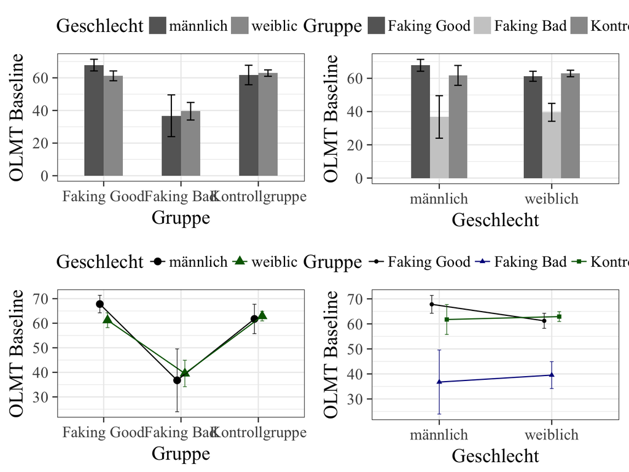

```r
library(ggplot2)
library(gridExtra)
abb6.58a1 <- ggplot(anova_zwei, aes(x=gruppe, y=b, fill=geschlecht))
p3 <- abb6.58a1+stat_summary(fun.y=mean, geom="bar", position="dodge", aes(width=0.5))+
  stat_summary(fun.data=mean_cl_normal, geom="errorbar", position=position_dodge(width=.5), width=.2)+
  labs(x="Gruppe", y="OLMT Baseline", fill="Geschlecht")+
  theme_bw(base_size = 18, base_family="Times New Roman")+
  scale_fill_manual(values=c("grey40", "grey60"))+
  theme(legend.position="top")
abb6.58a2 <- ggplot(anova_zwei, aes(x=geschlecht, b, fill=gruppe))
p4 <- abb6.58a2+stat_summary(fun.y=mean, geom="bar", position="dodge", aes(width=.5))+
  stat_summary(fun.data=mean_cl_normal, geom="errorbar", position=position_dodge(width=.5), width=.2)+
  labs(x="Geschlecht", y="OLMT Baseline", fill="Gruppe")+
  theme_bw(base_size = 18, base_family="Times New Roman")+
  scale_fill_manual(values=c("grey40", "grey80", "grey60"))+
  theme(legend.position="top")
abb6.58b1 <- ggplot(anova_zwei, aes(x=gruppe, y=b, colour=geschlecht, shape=geschlecht))
p5 <- abb6.58b1+stat_summary(fun.y=mean, geom="point", size=3, position=position_dodge(width=.2))+
  stat_summary(fun.y=mean, geom="line", aes(group=geschlecht), position=position_dodge(width=.2))+
  stat_summary(fun.data=mean_cl_normal, geom="errorbar", width=.1, size=.25, position=position_dodge(width=.2))+
  labs(x="Gruppe",y="OLMT Baseline", colour="Geschlecht")+
  scale_color_manual(values=c("black", "darkgreen"))+
  theme_bw(base_size = 18, base_family="Times New Roman")+
  theme(legend.position="top")+
  scale_shape_discrete(name="Geschlecht")

abb6.58b2 <- ggplot(anova_zwei, aes(geschlecht, b, colour=gruppe, shape=gruppe))
p6 <- abb6.58b2+stat_summary(fun.y=mean, geom="point", position=position_dodge(width=.2))+
  stat_summary(fun.y=mean, geom="line", aes(group=gruppe), position=position_dodge(width=.2))+
  stat_summary(fun.data=mean_cl_normal, geom="errorbar", width=.1, size=.25, position=position_dodge(width=.2))+
  labs(x="Geschlecht",y="OLMT Baseline", colour="Gruppe")+
  scale_color_manual(values=c("black", "darkblue", "darkgreen"))+
  theme_bw(base_size = 18, base_family="Times New Roman")+
  theme(legend.position="top")+
  scale_shape_discrete(name="Gruppe")

grid.arrange(p3, p4, p5, p6, nrow=2, ncol=2)
```

Um zu vermeiden, dass es zu Fehlern kommt, nehmen wir wieder alle Pakete raus.

```r
detachAllPackages()
```

## 1.4 Einfaktorielle ANOVA mit MW

```r
library(foreign)
anova.mw <- read.spss("ANOVA mit MW voll.sav", to.data.frame=T, use.value.labels=T)
```

```
## re-encoding from CP1252
```

```r
anova.mw$VP <- factor(c(1:339))
names(anova.mw)
```

```
## [1] "Ehrlich"    "Fake_Good"  "Primed"     "geschlecht" "VP"
```

```r
nrow(anova.mw)
```

```
## [1] 339
```

```r
tail(anova.mw)
```

```
##     Ehrlich Fake_Good    Primed geschlecht  VP
## 334     113        77 112.86085   weiblich 334
## 335     102       102 103.04887   weiblich 335
## 336      72        28 116.15630   weiblich 336
## 337      90        53 133.37646   weiblich 337
## 338     111       106  91.60061   weiblich 338
## 339      98       103 142.29378   weiblich 339
```

```r
is.factor(anova.mw$VP)
```

```
## [1] TRUE
```

```r
library(reshape2)
#falls geöffnet, unbedingt package reshape schließen
anova.mw.long <-  melt(anova.mw,
                       # ID variablen - werden wieder als Spalten auftauchen
                       id.vars=c("VP","geschlecht"),
                       # Spalten, in denen die Werte stehen, die untereinander auftauchen sollen
                       measure.vars=c("Ehrlich", "Fake_Good", "Primed"),
                       # Name der Spalte mit den Messwerten
                       variable.name="Messzeitpunkt",
                       value.name="Neurotizismus")
anova.mw.long <- anova.mw.long[order(anova.mw.long$VP),]
names(anova.mw.long)
```

```
## [1] "VP"            "geschlecht"    "Messzeitpunkt" "Neurotizismus"
```

```r
head(anova.mw.long)
```

```
##     VP geschlecht Messzeitpunkt Neurotizismus
## 1    1   männlich       Ehrlich      88.00000
## 340  1   männlich     Fake_Good      88.00000
## 679  1   männlich        Primed     131.39926
## 2    2   männlich       Ehrlich     106.00000
## 341  2   männlich     Fake_Good      70.00000
## 680  2   männlich        Primed      89.42068
```

```r
lev <- levels(anova.mw.long$Messzeitpunkt)
lev
```

```
## [1] "Ehrlich"   "Fake_Good" "Primed"
```

```r
length(lev)
```

```
## [1] 3
```

```r
library(psych)
desc_mw <- describeBy(anova.mw.long$Neurotizismus, group=anova.mw.long$Messzeitpunkt)
desc_mw
```

```
## $Ehrlich
##    vars   n  mean    sd median trimmed   mad min max range skew kurtosis
## X1    1 339 93.53 24.42     91   93.27 23.72  28 156   128  0.1    -0.26
##      se
## X1 1.33
##
## $Fake_Good
##    vars   n  mean    sd median trimmed   mad min max range skew kurtosis
## X1    1 339 71.27 29.59     66    69.9 29.65   9 155   146 0.42    -0.43
##      se
## X1 1.61
##
## $Primed
##    vars   n   mean    sd median trimmed   mad   min    max  range  skew
## X1    1 339 121.61 19.03 121.97  121.96 20.06 65.46 181.27 115.81 -0.15
##    kurtosis   se
## X1    -0.16 1.03
##
## attr(,"call")
## by.default(data = x, INDICES = group, FUN = describe, type = type)
```

Eigentliche ANOVA.

```r
library(afex)
out5a <- aov_car(Neurotizismus~Error(VP/Messzeitpunkt),
data=anova.mw.long, return="univariate")
out5b <- aov_car(Neurotizismus~Error(VP/Messzeitpunkt),
data=anova.mw.long)
out6a <- anova(out5b, es="pes", correction="none", intercept=T)
out6b <- anova(out5b, es="pes", correction="GG")
out6c <- anova(out5b, es="pes", correction="HF")
out5a
```

```
##
## Univariate Type III Repeated-Measures ANOVA Assuming Sphericity
##
##                    SS num Df Error SS den Df        F    Pr(>F)
## (Intercept)   9268815      1   240051    338 13050.81 < 2.2e-16 ***
## Messzeitpunkt  431449      2   379872    676   383.89 < 2.2e-16 ***
## ---
## Signif. codes:  0 '***' 0.001 '**' 0.01 '*' 0.05 '.' 0.1 ' ' 1
##
##
## Mauchly Tests for Sphericity
##
##               Test statistic    p-value
## Messzeitpunkt        0.78754 3.3262e-18
##
##
## Greenhouse-Geisser and Huynh-Feldt Corrections
##  for Departure from Sphericity
##
##                GG eps Pr(>F[GG])
## Messzeitpunkt 0.82477  < 2.2e-16 ***
## ---
## Signif. codes:  0 '***' 0.001 '**' 0.01 '*' 0.05 '.' 0.1 ' ' 1
##
##                  HF eps   Pr(>F[HF])
## Messzeitpunkt 0.8282934 2.034798e-93
```

```r
out6 <- rbind(out6a, out6b, out6c)
out6
```

```
## Anova Table (Type 3 tests)
##
## Response: Neurotizismus
##                num Df den Df    MSE        F     pes    Pr(>F)
## (Intercept)    1.0000 338.00 710.21 13050.81 0.97476 < 2.2e-16 ***
## Messzeitpunkt  2.0000 676.00 561.94   383.89 0.53179 < 2.2e-16 ***
## Messzeitpunkt1 1.6495 557.54 681.33   383.89 0.53179 < 2.2e-16 ***
## Messzeitpunkt2 1.6566 559.93 678.43   383.89 0.53179 < 2.2e-16 ***
## ---
## Signif. codes:  0 '***' 0.001 '**' 0.01 '*' 0.05 '.' 0.1 ' ' 1
```

```r
#Teststärke
library(pwr)
pwr.f2.test(u=2, v=667, sig.level=.05, f2=.53/(1-.53))
```

```
##
##      Multiple regression power calculation
##
##               u = 2
##               v = 667
##              f2 = 1.12766
##       sig.level = 0.05
##           power = 1
```

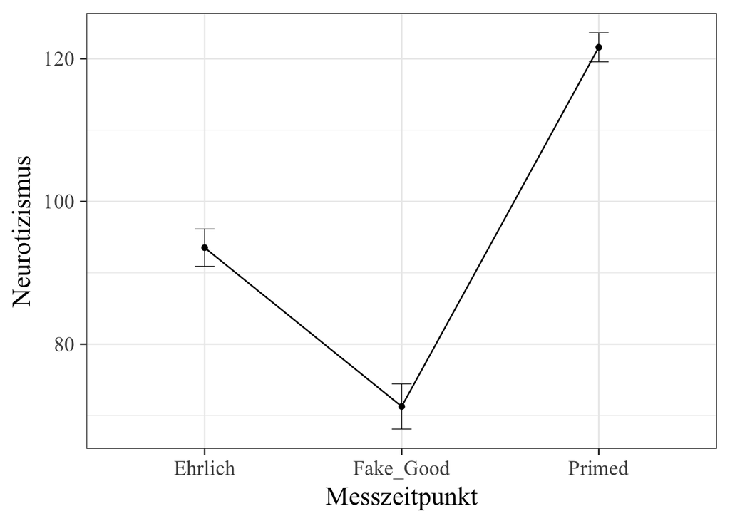

```r
#Abbildung des Verlaufs
library(ggplot2)
abb6.85 <- ggplot(anova.mw.long, aes(Messzeitpunkt, Neurotizismus))
abb6.85+stat_summary(fun.y=mean, geom="point")+
  stat_summary(fun.y=mean, geom="line", aes(group=1))+
  stat_summary(fun.data=mean_cl_normal, geom="errorbar", width=.1, size=.25)+
  theme_bw(base_size = 18, base_family="Times New Roman")+
  theme(legend.position="top")
```

Um zu vermeiden, dass es zu Fehlern kommt, nehmen wir wieder alle Pakete raus.

```r
detachAllPackages()
```

## 1.5 Friedman-Test

```r
library(stats)
anova.mw.long$N_rank <- ave(anova.mw.long$Neurotizismus, anova.mw.long$VP,
FUN=rank)
library(psych)
desc_fried1 <- describeBy(anova.mw.long$Neurotizismus, group=anova.mw.long$
Messzeitpunkt)
desc_fried1
```

```
## $Ehrlich
##    vars   n  mean    sd median trimmed   mad min max range skew kurtosis
## X1    1 339 93.53 24.42     91   93.27 23.72  28 156   128  0.1    -0.26
##      se
## X1 1.33
##
## $Fake_Good
##    vars   n  mean    sd median trimmed   mad min max range skew kurtosis
## X1    1 339 71.27 29.59     66    69.9 29.65   9 155   146 0.42    -0.43
##      se
## X1 1.61
##
## $Primed
##    vars   n   mean    sd median trimmed   mad   min    max  range  skew
## X1    1 339 121.61 19.03 121.97  121.96 20.06 65.46 181.27 115.81 -0.15
##    kurtosis   se
## X1    -0.16 1.03
##
## attr(,"call")
## by.default(data = x, INDICES = group, FUN = describe, type = type)
```

```r
desc_fried2 <- describeBy(anova.mw.long$N_rank, group=anova.mw.long$Messzeitpunkt)
desc_fried2
```

```
## $Ehrlich
##    vars   n mean   sd median trimmed mad min max range skew kurtosis   se
## X1    1 339 2.05 0.57      2    2.06   0   1   3     2 0.04    -0.07 0.03
##
## $Fake_Good
##    vars   n mean   sd median trimmed mad min max range skew kurtosis   se
## X1    1 339  1.3 0.52      1    1.22   0   1   3     2  1.5     1.33 0.03
##
## $Primed
##    vars   n mean  sd median trimmed mad min max range  skew kurtosis   se
## X1    1 339 2.65 0.7      3     2.8   0   1   3     2 -1.66      1.1 0.04
##
## attr(,"call")
## by.default(data = x, INDICES = group, FUN = describe, type = type)
```

Friedman-Test

```r
fried <- friedman.test(Neurotizismus~Messzeitpunkt | VP, anova.mw.long)
fried
```

```
##
##  Friedman rank sum test
##
## data:  Neurotizismus and Messzeitpunkt and VP
## Friedman chi-squared = 308.9, df = 2, p-value < 2.2e-16
```

Um zu vermeiden, dass es zu Fehlern kommt, nehmen wir wieder alle Pakete raus.

```r
detachAllPackages()
```

## 1.6 Zweifaktorielle ANOVA mit MW

```r
library(foreign)
gd <- read.spss("Gemischtes Design.sav", to.data.frame=T, use.value.labels=T)
```

```
## re-encoding from CP1252
```

```r
names(gd)
```

```
## [1] "Ehrlich"    "Fake_Good"  "Primed"     "geschlecht"
```

```r
nrow(gd)
```

```
## [1] 339
```

```r
head(gd)
```

```
##   Ehrlich Fake_Good    Primed geschlecht
## 1      88        88 131.39926   männlich
## 2     106        70  89.42068   männlich
## 3     146        31 135.88124   männlich
## 4      63        42 121.88463   männlich
## 5      67        58 103.96562   männlich
## 6     110        65 132.12660   männlich
```

```r
#Zunächste brauchen wir eine Variable VP
gd$VP <- factor(c(1:339))
#Nun müssen wir den Datensatz ins long Format kippen
library(reshape2)
gd.long <-  melt(gd,
                       # ID variablen - werden wieder als Spalten auftauchen
                       id.vars=c("VP","geschlecht"),
                       # Spalten, in denen die Werte stehen, die untereinander auftauchen sollen
                       measure.vars=c("Ehrlich", "Fake_Good", "Primed"),
                       # Name der Spalte mit den Messwerten
                       variable.name="Messzeitpunkt",
                       value.name="Neurotizismus")
gd.long <- gd.long[order(gd.long$VP),]
names(gd.long)
```

```
## [1] "VP"            "geschlecht"    "Messzeitpunkt" "Neurotizismus"
```

```r
head(gd.long)
```

```
##     VP geschlecht Messzeitpunkt Neurotizismus
## 1    1   männlich       Ehrlich      88.00000
## 340  1   männlich     Fake_Good      88.00000
## 679  1   männlich        Primed     131.39926
## 2    2   männlich       Ehrlich     106.00000
## 341  2   männlich     Fake_Good      70.00000
## 680  2   männlich        Primed      89.42068
```

```r
#Deskriptive Statistiken
levels(gd.long$Messzeitpunkt)
```

```
## [1] "Ehrlich"   "Fake_Good" "Primed"
```

```r
table(gd$geschlecht)
```

```
##
## männlich weiblich
##       69      270
```

```r
detachAllPackages()
library(reshape)
library(psych)
desc_gd1 <- cast(data = gd.long,
                  formula=geschlecht~Messzeitpunkt,
                  value="Neurotizismus",
                  fun.aggregate=describe)
desc_gd1
```

```
##   geschlecht Ehrlich_vars Ehrlich_n Ehrlich_mean Ehrlich_sd Ehrlich_median
## 1   männlich            1        69     80.62319   21.02527             81
## 2   weiblich            1       270     96.82593   24.15831             95
##   Ehrlich_trimmed Ehrlich_mad Ehrlich_min Ehrlich_max Ehrlich_range
## 1        80.08772     19.2738          30         146           116
## 2        96.81019     25.2042          28         156           128
##   Ehrlich_skew Ehrlich_kurtosis Ehrlich_se Fake_Good_vars Fake_Good_n
## 1  0.329563050        0.5173562   2.531145              1          69
## 2  0.003605785       -0.2653164   1.470228              1         270
##   Fake_Good_mean Fake_Good_sd Fake_Good_median Fake_Good_trimmed
## 1       63.00000     23.20940               65          62.59649
## 2       73.37815     30.69388               68          72.09259
##   Fake_Good_mad Fake_Good_min Fake_Good_max Fake_Good_range Fake_Good_skew
## 1       26.6868            19           119             100      0.1501073
## 2       29.6520             9           155             146      0.3736967
##   Fake_Good_kurtosis Fake_Good_se Primed_vars Primed_n Primed_mean
## 1         -0.4382585     2.794084           1       69    118.6492
## 2         -0.6069136     1.867970           1      270    122.3618
##   Primed_sd Primed_median Primed_trimmed Primed_mad Primed_min Primed_max
## 1  17.55212      116.6003       118.8565   18.00271   76.07309   162.9206
## 2  19.35346      123.5232       122.7801   20.58767   65.45942   181.2696
##   Primed_range Primed_skew Primed_kurtosis Primed_se
## 1     86.84751 -0.04202808     -0.09434975  2.113027
## 2    115.81014 -0.18696775     -0.17649600  1.177814
```

```r
desc_gd2 <- describeBy(gd.long$Neurotizismus, group=gd.long$Messzeitpunkt)
desc_gd2
```

```
## $Ehrlich
##    vars   n  mean    sd median trimmed   mad min max range skew kurtosis
## X1    1 339 93.53 24.42     91   93.27 23.72  28 156   128  0.1    -0.26
##      se
## X1 1.33
##
## $Fake_Good
##    vars   n  mean    sd median trimmed   mad min max range skew kurtosis
## X1    1 339 71.27 29.59     66    69.9 29.65   9 155   146 0.42    -0.43
##      se
## X1 1.61
##
## $Primed
##    vars   n   mean    sd median trimmed   mad   min    max  range  skew
## X1    1 339 121.61 19.03 121.97  121.96 20.06 65.46 181.27 115.81 -0.15
##    kurtosis   se
## X1    -0.16 1.03
##
## attr(,"call")
## by.default(data = x, INDICES = group, FUN = describe, type = type)
```

```r
library(lawstat)
Levene2a <- levene.test(gd$Ehrlich, gd$geschlecht, location="mean")
Levene2b <- levene.test(gd$Fake_Good, gd$geschlecht, location ="mean")
Levene2c <- levene.test(gd$Primed, gd$geschlecht, location ="mean")
Forsythe2a <- levene.test(gd$Ehrlich, gd$geschlecht, location ="median")
Forsythe2b <- levene.test(gd$Fake_Good, gd$geschlecht, location ="median")
Forsythe2c <- levene.test(gd$Primed, gd$geschlecht, location ="median")
lev <- rbind(Levene2a, Levene2b, Levene2c)
fors <- rbind(Forsythe2a, Forsythe2b, Forsythe2c)
rbind(lev, fors)
```

```
##            statistic p.value
## Levene2a   3.472347  0.06327234
## Levene2b   10.59701  0.00124767
## Levene2c   1.391925  0.2389125
## Forsythe2a 3.384896  0.06667567
## Forsythe2b 8.695531  0.00341271
## Forsythe2c 1.465496  0.226906
##            method
## Levene2a   "classical Levene's test based on the absolute deviations from the mean ( none not applied because t" [truncated]
## Levene2b   "classical Levene's test based on the absolute deviations from the mean ( none not applied because t" [truncated]
## Levene2c   "classical Levene's test based on the absolute deviations from the mean ( none not applied because t" [truncated]
## Forsythe2a "modified robust Brown-Forsythe Levene-type test based on the absolute deviations from the median"
## Forsythe2b "modified robust Brown-Forsythe Levene-type test based on the absolute deviations from the median"
## Forsythe2c "modified robust Brown-Forsythe Levene-type test based on the absolute deviations from the median"
##            data.name      non.bootstrap.p.value
## Levene2a   "gd$Ehrlich"   0.06327234
## Levene2b   "gd$Fake_Good" 0.00124767
## Levene2c   "gd$Primed"    0.2389125
## Forsythe2a "gd$Ehrlich"   0.06667567
## Forsythe2b "gd$Fake_Good" 0.00341271
## Forsythe2c "gd$Primed"    0.226906
```

Eigentliche ANOVA

```r
library(afex)
out7a <- aov_car(Neurotizismus~geschlecht+Error(VP/Messzeitpunkt),
                data=gd.long, return="univariate")
```

```
## Contrasts set to contr.sum for the following variables: geschlecht
```

```r
out7b <- aov_car(Neurotizismus~geschlecht+Error(VP/Messzeitpunkt),
                 data=gd.long)
```

```
## Contrasts set to contr.sum for the following variables: geschlecht
```

```r
out8a <- anova(out7b, es="pes", correction="none", intercept=T)
out8b <- anova(out7b, es="pes", correction="GG")
out8c <- anova(out7b, es="pes", correction="HF")

out7a
```

```
##
## Univariate Type III Repeated-Measures ANOVA Assuming Sphericity
##
##                               SS num Df Error SS den Df         F
## (Intercept)              5639293      1   223240    337 8512.9923
## geschlecht                 16811      1   223240    337   25.3774
## Messzeitpunkt             305462      2   375579    674  274.0854
## geschlecht:Messzeitpunkt    4293      2   375579    674    3.8522
##                             Pr(>F)
## (Intercept)              < 2.2e-16 ***
## geschlecht               7.701e-07 ***
## Messzeitpunkt            < 2.2e-16 ***
## geschlecht:Messzeitpunkt    0.0217 *
## ---
## Signif. codes:  0 '***' 0.001 '**' 0.01 '*' 0.05 '.' 0.1 ' ' 1
##
##
## Mauchly Tests for Sphericity
##
##                          Test statistic    p-value
## Messzeitpunkt                   0.78456 1.9824e-18
## geschlecht:Messzeitpunkt        0.78456 1.9824e-18
##
##
## Greenhouse-Geisser and Huynh-Feldt Corrections
##  for Departure from Sphericity
##
##                           GG eps Pr(>F[GG])
## Messzeitpunkt            0.82275    < 2e-16 ***
## geschlecht:Messzeitpunkt 0.82275    0.02935 *
## ---
## Signif. codes:  0 '***' 0.001 '**' 0.01 '*' 0.05 '.' 0.1 ' ' 1
##
##                             HF eps   Pr(>F[HF])
## Messzeitpunkt            0.8262558 4.063196e-73
## geschlecht:Messzeitpunkt 0.8262558 2.917612e-02
```

```r
out8 <- rbind(out8a, out8b, out8c)
out8
```

```
## Anova Table (Type 3 tests)
##
## Response: Neurotizismus
##                           num Df den Df    MSE         F     pes    Pr(>F)
## (Intercept)               1.0000 337.00 662.43 8512.9923 0.96192 < 2.2e-16
## geschlecht                1.0000 337.00 662.43   25.3774 0.07003 7.701e-07
## Messzeitpunkt             2.0000 674.00 557.24  274.0854 0.44852 < 2.2e-16
## geschlecht:Messzeitpunkt  2.0000 674.00 557.24    3.8522 0.01130   0.02170
## geschlecht1               1.0000 337.00 662.43   25.3774 0.07003 7.701e-07
## Messzeitpunkt1            1.6455 554.53 677.29  274.0854 0.44852 < 2.2e-16
## geschlecht:Messzeitpunkt1 1.6455 554.53 677.29    3.8522 0.01130   0.02935
## geschlecht2               1.0000 337.00 662.43   25.3774 0.07003 7.701e-07
## Messzeitpunkt2            1.6525 556.90 674.41  274.0854 0.44852 < 2.2e-16
## geschlecht:Messzeitpunkt2 1.6525 556.90 674.41    3.8522 0.01130   0.02918
##
## (Intercept)               ***
## geschlecht                ***
## Messzeitpunkt             ***
## geschlecht:Messzeitpunkt  *
## geschlecht1               ***
## Messzeitpunkt1            ***
## geschlecht:Messzeitpunkt1 *
## geschlecht2               ***
## Messzeitpunkt2            ***
## geschlecht:Messzeitpunkt2 *
## ---
## Signif. codes:  0 '***' 0.001 '**' 0.01 '*' 0.05 '.' 0.1 ' ' 1
```

```r
#Teststärke
library(pwr)
pwr.f2.test(u=1, v=337, sig.level=.05, f2=.07/(1-.07))
```

```
##
##      Multiple regression power calculation
##
##               u = 1
##               v = 337
##              f2 = 0.07526882
##       sig.level = 0.05
##           power = 0.9989543
```

```r
pwr.f2.test(u=2, v=674, sig.level=.05, f2=.45/(1-.45))
```

```
##
##      Multiple regression power calculation
##
##               u = 2
##               v = 674
##              f2 = 0.8181818
##       sig.level = 0.05
##           power = 1
```

```r
pwr.f2.test(u=2, v=674, sig.level=.05, f2=.01/(1-.01))
```

```
##
##      Multiple regression power calculation
##
##               u = 2
##               v = 674
##              f2 = 0.01010101
##       sig.level = 0.05
##           power = 0.6424524
```

Interaktionsdiagramm

```r
library(ggplot2)
library(gridExtra)
names(gd.long)
```

```
## [1] "VP"            "geschlecht"    "Messzeitpunkt" "Neurotizismus"
```

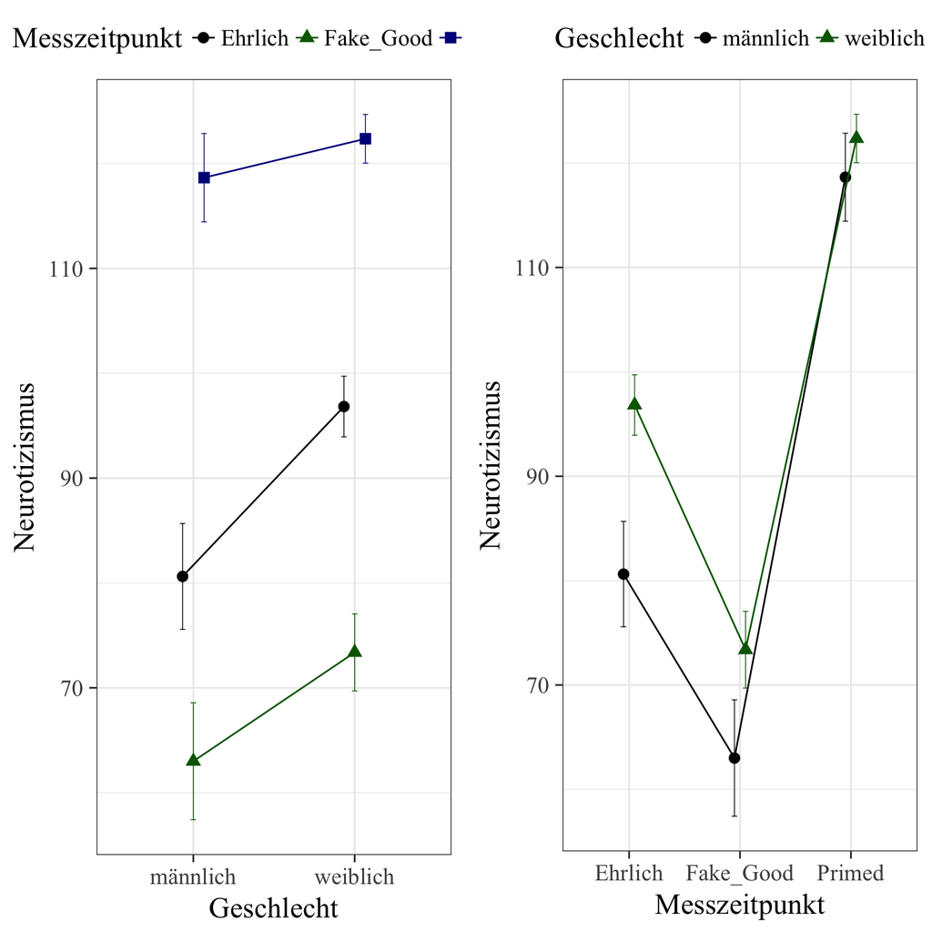

```r
abb6.126a <- ggplot(gd.long, aes(geschlecht, Neurotizismus, shape=Messzeitpunkt, colour=Messzeitpunkt))
p7 <- abb6.126a+stat_summary(fun.y=mean, geom="point", size=3, position=position_dodge(width=.2))+
  stat_summary(fun.y=mean, geom="line", aes(group=Messzeitpunkt), position=position_dodge(width=.2))+
  stat_summary(fun.data=mean_cl_normal, geom="errorbar", width=.1, size=.25, position=position_dodge(width=.2))+
  labs(x="Geschlecht",y="Neurotizismus", colour="Messzeitpunkt")+
  scale_color_manual(values=c("black", "darkgreen", "darkblue"))+
  theme_bw(base_size = 18, base_family="Times New Roman")+
  theme(legend.position="top")+
  scale_shape_discrete(name="Messzeitpunkt")

abb6.126b <- ggplot(gd.long, aes(Messzeitpunkt, Neurotizismus, shape=geschlecht, colour=geschlecht))
p8 <- abb6.126b+stat_summary(fun.y=mean, geom="point", size=3, position=position_dodge(width=.2))+
  stat_summary(fun.y=mean, geom="line", aes(group=geschlecht), position=position_dodge(width=.2))+
  stat_summary(fun.data=mean_cl_normal, geom="errorbar", width=.1, size=.25, position=position_dodge(width=.2))+
  labs(x="Messzeitpunkt",y="Neurotizismus", colour="Geschlecht")+
  scale_color_manual(values=c("black", "darkgreen"))+
  theme_bw(base_size = 18, base_family="Times New Roman")+
  theme(legend.position="top")+
  scale_shape_discrete(name="Geschlecht")

grid.arrange(p7, p8, ncol=2)
```

## 1.7 A priori Kontraste

```r
library(afex)
library(lsmeans)
out9 <- aov_ez(id="vpn", dv="b", data=anova_ein, between = "gruppe",
               return = "aov")
```

```
## Contrasts set to contr.sum for the following variables: gruppe
```

```r
means <- lsmeans(out9, ~gruppe)
#means
contrasts <- list(
  Kontrast_1=c(-1, 0, 1),
  Kontrast_2=c(-.5, 1, -.5))
con1 <- contrast(means, contrasts, adjust = "none")
con1
```

```
##  contrast     estimate       SE  df t.ratio p.value
##  Kontrast_1  -1.389183 2.400535 116  -0.579  0.5639
##  Kontrast_2 -24.588494 2.043078 116 -12.035  <.0001
```

```r
#Durchführung der criterion power Analyse
describeBy(anova_ein$b, group=anova_ein$gruppe)
```

```
## $`Faking Good`
##    vars  n  mean   sd median trimmed  mad   min   max range skew kurtosis
## X1    1 37 64.07 7.35     63   63.99 7.41 49.33 81.33    32 0.15    -0.59
##      se
## X1 1.21
##
## $`Faking Bad`
##    vars  n  mean    sd median trimmed   mad min max range  skew kurtosis
## X1    1 41 38.79 15.58  38.33   39.11 20.76   6  63    57 -0.06    -1.13
##      se
## X1 2.43
##
## $Kontrollgruppe
##    vars  n  mean   sd median trimmed  mad min   max range skew kurtosis
## X1    1 41 62.68 5.79  61.33   62.51 3.96  50 75.67 25.67 0.34    -0.09
##     se
## X1 0.9
##
## attr(,"call")
## by.default(data = x, INDICES = group, FUN = describe, type = type)
```

```r
##gepoolte SD
n1=37
n2=41
sd1=7.35
sd2=5.79
sd_pooled=sqrt(((n1-1)*sd1^2+(n2-1)*sd2^2)/(n1+n2-2))
sd_pooled
```

```
## [1] 6.575247
```

```r
g=(64.07-62.68)/sd_pooled
g
```

```
## [1] 0.2113989
```

```r
library(pwr)
table(anova_ein$gruppe)
```

```
##
##    Faking Good     Faking Bad Kontrollgruppe
##             37             41             41
```

```r
pwr.t2n.test(n1=37, n2=41, d=g, sig.level=NULL, power=.95, alternative="greater")
```

```
##
##      t test power calculation
##
##              n1 = 37
##              n2 = 41
##               d = 0.2113989
##       sig.level = 0.7624342
##           power = 0.95
##     alternative = greater
```

```r
#Kontrastalternativen

#Abweichung
contrast(means, method = "eff")
```

```
##  contrast                estimate       SE  df t.ratio p.value
##  Faking Good effect      8.890756 1.397745 116   6.361  <.0001
##  Faking Bad effect     -16.392329 1.362052 116 -12.035  <.0001
##  Kontrollgruppe effect   7.501573 1.362052 116   5.508  <.0001
##
## P value adjustment: fdr method for 3 tests
```

```r
#Einfach
out10 <- aov_ez(id="VP", dv="Neurotizismus", data=anova.mw.long, within = "Messzeitpunkt",
               return = "aov")
means2 <- lsmeans(out10, ~Messzeitpunkt)
con2 <- contrast(means2, method = "trt.vs.ctrl", ref=1)
con2
```

```
##  contrast             estimate       SE  df t.ratio p.value
##  Fake_Good - Ehrlich -22.26224 1.820792 676 -12.227  <.0001
##  Primed - Ehrlich     28.07808 1.820792 676  15.421  <.0001
##
## P value adjustment: dunnettx method for 2 tests
```

```r
#contrast(means, method = "trt.vs.ctrl", ref=3)

#Differenz
Differenz <- list(
  Eins_vs_2=c(-1, 1, 0),
  Zwei_vs_3=c(0, -1, 1))
contrast(means, Differenz, adjust = "none")
```

```
##  contrast   estimate       SE  df t.ratio p.value
##  Eins_vs_2 -25.28309 2.400535 116 -10.532  <.0001
##  Zwei_vs_3  23.89390 2.338172 116  10.219  <.0001
```

```r
#Helmert
Helmert<- list(
  Eins=c(-1, .5, .5),
  Zwei=c(0, -1, 1))
contrast(means, Helmert, adjust = "none")
```

```
##  contrast  estimate       SE  df t.ratio p.value
##  Eins     -13.33613 2.096617 116  -6.361  <.0001
##  Zwei      23.89390 2.338172 116  10.219  <.0001
```

```r
#wiederholt
wiederholt <- list(
  Eins_vs_2=c(1, -1, 0),
  Zwei_vs_3=c(0, 1, -1))
con3 <- contrast(means, wiederholt, adjust = "none")
con3
```

```
##  contrast   estimate       SE  df t.ratio p.value
##  Eins_vs_2  25.28309 2.400535 116  10.532  <.0001
##  Zwei_vs_3 -23.89390 2.338172 116 -10.219  <.0001
```

```r
confint(con3)
```

```
##  contrast   estimate       SE  df  lower.CL  upper.CL
##  Eins_vs_2  25.28309 2.400535 116  20.52852  30.03765
##  Zwei_vs_3 -23.89390 2.338172 116 -28.52495 -19.26286
##
## Confidence level used: 0.95
```

```r
#Polynomial
contrast(means2, method="poly", adjust = "none")
```

```
##  contrast  estimate       SE  df t.ratio p.value
##  linear    28.07808 1.820792 676  15.421  <.0001
##  quadratic 72.60257 3.153704 676  23.021  <.0001
```

## 1.8 post hoc Tests und Scheffe

### 1.8.1 post hoc für ANOVA mit Messwiederholung

```r
con4 <- contrast(means2, method="pairwise", adjust = "bon")
con4
```

```
##  contrast             estimate       SE  df t.ratio p.value
##  Ehrlich - Fake_Good  22.26224 1.820792 676  12.227  <.0001
##  Ehrlich - Primed    -28.07808 1.820792 676 -15.421  <.0001
##  Fake_Good - Primed  -50.34033 1.820792 676 -27.647  <.0001
##
## P value adjustment: bonferroni method for 3 tests
```

```r
confint(con4)
```

```
##  contrast             estimate       SE  df  lower.CL  upper.CL
##  Ehrlich - Fake_Good  22.26224 1.820792 676  17.89243  26.63206
##  Ehrlich - Primed    -28.07808 1.820792 676 -32.44790 -23.70827
##  Fake_Good - Primed  -50.34033 1.820792 676 -54.71014 -45.97051
##
## Confidence level used: 0.95
## Conf-level adjustment: bonferroni method for 3 estimates
```

### 1.8.2 post hoc für ANOVA ohne Messwiederholung

```r
con5a <- contrast(means, method="pairwise", adjust = "none")
con5b <- contrast(means, method="pairwise", adjust = "bon")
con5a
```

```
##  contrast                       estimate       SE  df t.ratio p.value
##  Faking Good - Faking Bad      25.283085 2.400535 116  10.532  <.0001
##  Faking Good - Kontrollgruppe   1.389183 2.400535 116   0.579  0.5639
##  Faking Bad - Kontrollgruppe  -23.893902 2.338172 116 -10.219  <.0001
```

```r
con5b
```

```
##  contrast                       estimate       SE  df t.ratio p.value
##  Faking Good - Faking Bad      25.283085 2.400535 116  10.532  <.0001
##  Faking Good - Kontrollgruppe   1.389183 2.400535 116   0.579  1.0000
##  Faking Bad - Kontrollgruppe  -23.893902 2.338172 116 -10.219  <.0001
##
## P value adjustment: bonferroni method for 3 tests
```

```r
confint(con5a)
```

```
##  contrast                       estimate       SE  df   lower.CL
##  Faking Good - Faking Bad      25.283085 2.400535 116  20.528524
##  Faking Good - Kontrollgruppe   1.389183 2.400535 116  -3.365379
##  Faking Bad - Kontrollgruppe  -23.893902 2.338172 116 -28.524947
##    upper.CL
##   30.037646
##    6.143744
##  -19.262857
##
## Confidence level used: 0.95
```

```r
confint(con5b)
```

```
##  contrast                       estimate       SE  df   lower.CL
##  Faking Good - Faking Bad      25.283085 2.400535 116  19.451722
##  Faking Good - Kontrollgruppe   1.389183 2.400535 116  -4.442181
##  Faking Bad - Kontrollgruppe  -23.893902 2.338172 116 -29.573776
##    upper.CL
##   31.114448
##    7.220546
##  -18.214029
##
## Confidence level used: 0.95
## Conf-level adjustment: bonferroni method for 3 estimates
```

### 1.8.3 Scheffé

```r
library(agricolae)
scheffe.test(out9,"gruppe", alpha=.05, console=TRUE)
```

```
##
## Study: out9 ~ "gruppe"
##
## Scheffe Test for b
##
## Mean Square Error  : 112.0745
##
## gruppe,  means
##
##                       b       std  r   Min   Max
## Faking Bad     38.78854 15.584761 41  6.00 63.00
## Faking Good    64.07162  7.347935 37 49.33 81.33
## Kontrollgruppe 62.68244  5.791236 41 50.00 75.67
##
## alpha: 0.05 ; Df Error: 116
## Critical Value of F: 3.074447
##
## Harmonic Mean of Cell Sizes  39.57391
## Minimum Significant Difference: 5.901501
##
## Means with the same letter are not significantly different.
##
## Groups, Treatments and means
## a     Faking Good         64.07
## a     Kontrollgruppe      62.68
## b     Faking Bad          38.79
```

## 1.9 Trendtest

```r
con6 <- contrast(means2, method="poly")
con6
```

```
##  contrast  estimate       SE  df t.ratio p.value
##  linear    28.07808 1.820792 676  15.421  <.0001
##  quadratic 72.60257 3.153704 676  23.021  <.0001
```

```r
confint(con6)
```

```
##  contrast  estimate       SE  df lower.CL upper.CL
##  linear    28.07808 1.820792 676 24.50300 31.65317
##  quadratic 72.60257 3.153704 676 66.41034 78.79480
##
## Confidence level used: 0.95
```

```r
library(compute.es)
tes(t=15.421, n.1=339, n.2=339, level=95)
```

```
## Mean Differences ES:
##
##  d [ 95 %CI] = 1.18 [ 1.02 , 1.35 ]
##   var(d) = 0.01
##   p-value(d) = 0
##   U3(d) = 88.19 %
##   CLES(d) = 79.89 %
##   Cliff's Delta = 0.6
##
##  g [ 95 %CI] = 1.18 [ 1.02 , 1.35 ]
##   var(g) = 0.01
##   p-value(g) = 0
##   U3(g) = 88.16 %
##   CLES(g) = 79.86 %
##
##  Correlation ES:
##
##  r [ 95 %CI] = 0.51 [ 0.45 , 0.56 ]
##   var(r) = 0
##   p-value(r) = 0
##
##  z [ 95 %CI] = 0.56 [ 0.49 , 0.64 ]
##   var(z) = 0
##   p-value(z) = 0
##
##  Odds Ratio ES:
##
##  OR [ 95 %CI] = 8.57 [ 6.37 , 11.53 ]
##   p-value(OR) = 0
##
##  Log OR [ 95 %CI] = 2.15 [ 1.85 , 2.44 ]
##   var(lOR) = 0.02
##   p-value(Log OR) = 0
##
##  Other:
##
##  NNT = 2.3
##  Total N = 678
```

```r
tes(t=23.021, n.1=339, n.2=339, level=95)
```

```
## Mean Differences ES:
##
##  d [ 95 %CI] = 1.77 [ 1.59 , 1.95 ]
##   var(d) = 0.01
##   p-value(d) = 0
##   U3(d) = 96.15 %
##   CLES(d) = 89.44 %
##   Cliff's Delta = 0.79
##
##  g [ 95 %CI] = 1.77 [ 1.59 , 1.94 ]
##   var(g) = 0.01
##   p-value(g) = 0
##   U3(g) = 96.13 %
##   CLES(g) = 89.42 %
##
##  Correlation ES:
##
##  r [ 95 %CI] = 0.66 [ 0.62 , 0.7 ]
##   var(r) = 0
##   p-value(r) = 0
##
##  z [ 95 %CI] = 0.8 [ 0.72 , 0.87 ]
##   var(z) = 0
##   p-value(z) = 0
##
##  Odds Ratio ES:
##
##  OR [ 95 %CI] = 24.71 [ 17.9 , 34.12 ]
##   p-value(OR) = 0
##
##  Log OR [ 95 %CI] = 3.21 [ 2.88 , 3.53 ]
##   var(lOR) = 0.03
##   p-value(Log OR) = 0
##
##  Other:
##
##  NNT = 1.61
##  Total N = 678
```

```r
library(pwr)
pwr.t.test(n=339, d=1.18, sig.level=.05, type="paired")
```

```
##
##      Paired t test power calculation
##
##               n = 339
##               d = 1.18
##       sig.level = 0.05
##           power = 1
##     alternative = two.sided
##
## NOTE: n is number of *pairs*
```

```r
pwr.t.test(n=339, d=1.77, sig.level=.05, type="paired")
```

```
##
##      Paired t test power calculation
##
##               n = 339
##               d = 1.77
##       sig.level = 0.05
##           power = 1
##     alternative = two.sided
##
## NOTE: n is number of *pairs*
```

### 1.9.1 Vorgehen unabhängige Tests

```r
names(anova_ein)
```

```
## [1] "vpn"    "gruppe" "b"      "b_rank"
```

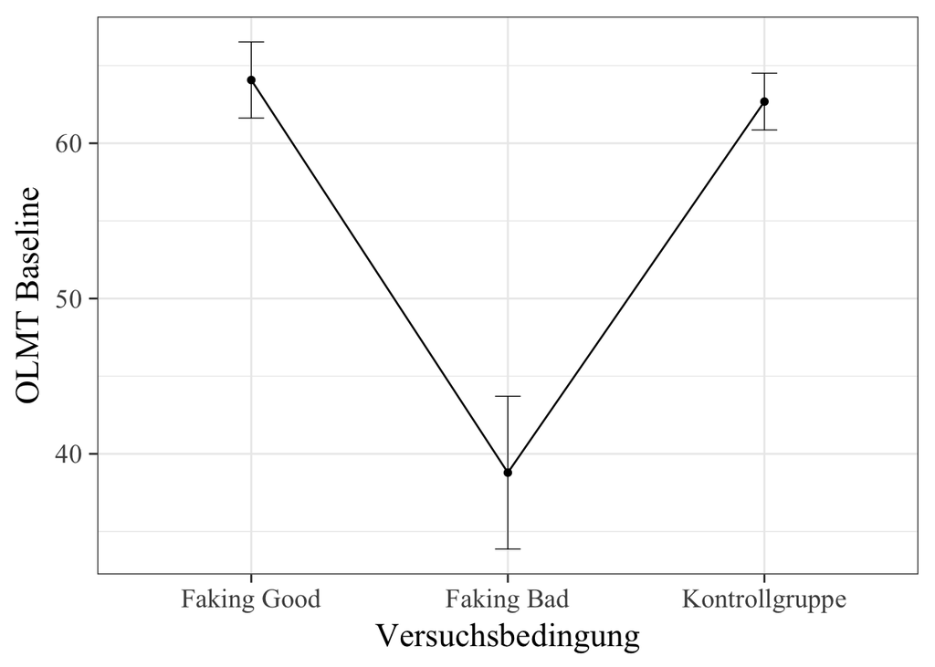

```r
abb6.143 <- ggplot(anova_ein, aes(gruppe, b))
abb6.143+stat_summary(fun.y=mean, geom="point")+
  stat_summary(fun.y=mean, geom="line", aes(group=1))+
  stat_summary(fun.data=mean_cl_normal, geom="errorbar", width=.1, size=.25)+
  theme_bw(base_size = 18, base_family="Times New Roman")+
  theme(legend.position="top")+
  labs(x="Versuchsbedingung",y="OLMT Baseline")
```

```r
con7 <- contrast(means, method="poly")
con7
```

```
##  contrast   estimate       SE  df t.ratio p.value
##  linear    -1.389183 2.400535 116  -0.579  0.5639
##  quadratic 49.176987 4.086155 116  12.035  <.0001
```

```r
confint(con7)
```

```
##  contrast   estimate       SE  df  lower.CL  upper.CL
##  linear    -1.389183 2.400535 116 -6.143744  3.365379
##  quadratic 49.176987 4.086155 116 41.083842 57.270133
##
## Confidence level used: 0.95
```

```r
library(compute.es)
table(anova_ein$gruppe)
```

```
##
##    Faking Good     Faking Bad Kontrollgruppe
##             37             41             41
```

```r
tes(t=-.579, n.1=37, n.2=41, level=95)
```

```
## Mean Differences ES:
##
##  d [ 95 %CI] = -0.13 [ -0.58 , 0.32 ]
##   var(d) = 0.05
##   p-value(d) = 0.56
##   U3(d) = 44.78 %
##   CLES(d) = 46.3 %
##   Cliff's Delta = -0.07
##
##  g [ 95 %CI] = -0.13 [ -0.58 , 0.32 ]
##   var(g) = 0.05
##   p-value(g) = 0.56
##   U3(g) = 44.83 %
##   CLES(g) = 46.34 %
##
##  Correlation ES:
##
##  r [ 95 %CI] = 0.07 [ -0.16 , 0.29 ]
##   var(r) = 0.01
##   p-value(r) = 0.57
##
##  z [ 95 %CI] = 0.07 [ -0.16 , 0.3 ]
##   var(z) = 0.01
##   p-value(z) = 0.57
##
##  Odds Ratio ES:
##
##  OR [ 95 %CI] = 0.79 [ 0.35 , 1.79 ]
##   p-value(OR) = 0.56
##
##  Log OR [ 95 %CI] = -0.24 [ -1.06 , 0.58 ]
##   var(lOR) = 0.17
##   p-value(Log OR) = 0.56
##
##  Other:
##
##  NNT = -28.82
##  Total N = 78
```

```r
n_1 <- 37+41
tes(t=12.035, n.1=n_1, n.2=41, level=95)
```

```
## Mean Differences ES:
##
##  d [ 95 %CI] = 2.32 [ 1.84 , 2.81 ]
##   var(d) = 0.06
##   p-value(d) = 0
##   U3(d) = 98.99 %
##   CLES(d) = 94.97 %
##   Cliff's Delta = 0.9
##
##  g [ 95 %CI] = 2.31 [ 1.83 , 2.79 ]
##   var(g) = 0.06
##   p-value(g) = 0
##   U3(g) = 98.95 %
##   CLES(g) = 94.86 %
##
##  Correlation ES:
##
##  r [ 95 %CI] = 0.74 [ 0.65 , 0.82 ]
##   var(r) = 0
##   p-value(r) = 0
##
##  z [ 95 %CI] = 0.96 [ 0.77 , 1.14 ]
##   var(z) = 0.01
##   p-value(z) = 0
##
##  Odds Ratio ES:
##
##  OR [ 95 %CI] = 67.41 [ 27.99 , 162.34 ]
##   p-value(OR) = 0
##
##  Log OR [ 95 %CI] = 4.21 [ 3.33 , 5.09 ]
##   var(lOR) = 0.2
##   p-value(Log OR) = 0
##
##  Other:
##
##  NNT = 1.37
##  Total N = 119
```

```r
library(pwr)
pwr.t2n.test(n1=37, n2=41, d=-.13, sig.level=.05)
```

```
##
##      t test power calculation
##
##              n1 = 37
##              n2 = 41
##               d = 0.13
##       sig.level = 0.05
##           power = 0.08744617
##     alternative = two.sided
```

```r
pwr.t2n.test(n1=n_1, n2=41, d=2.31, sig.level=.05)
```

```
##
##      t test power calculation
##
##              n1 = 78
##              n2 = 41
##               d = 2.31
##       sig.level = 0.05
##           power = 1
##     alternative = two.sided
```